# Soft Sediment Summaries

Ben Millard-Martin

Mon Apr 30 11:53:04 2018

# Setup

These blocks of code sets base for the subsequent analyses:  
- loads all necessary packages  
- set working directory  
- read in diversity abundance, diversity length, ysi and habitat  
- create wide data for Vegan package  
- recreate long data with 0 observations  
- clean ysi data(remove duplicates)  
- create wide temperature data from ysi data  
- merge temperature and habitat data with diversity abundance  
- assign levels and names to month objects  
Set working directory Read in data Reformat data  
- create wide data  
- clean YSI data  
- extract temperature data  
- merge temperature and habitat data with diversity abundance data  
- create new month labels Load Packages

```r
source("C:/Users/FABS/Desktop/Rwd_Ben/Soft_sed/working_files/Rscript/Soft_sediment/bivalve_base.R")
```

# Overview

A site sampling event is comprised of 15 random sample locations within the site boundaries. At these sample locations macrophyte diversity and cover, invertebrate diversity and abundance and bivalve diversity, abundance and size data were recorded. See protocol document for site locations and specifics.

In 2016 seasonal sites were Clam Garden Reference(hcg), Marten Beach(marten) and Piles Beach(piles). In 2017 Clam Garden Reference was replaced with Pruth Bay East(pbe) due to sediment characteristics. The 2016 methods used five 0.5m x 0.5m PVC quadrats for bivalves and were excavated to a depth of 20cm for each site sampling event.The 2017 methods used fifteen 0.25m x 0.25m steel box quadrats for bivalves and were excavated to a depth of 10cm for each site sampling event. For further details on the methods please see protocol documents.

Due to the diffenences in methodology between years, count data cannot be directly compared because of differences in effort. Bivalve abundance is therefore presented as densities rather than counts per quadrat or site visit. In addition to informing on the ecology of these systems, these summaries also provide insight into diffences between methods and the potential limitations of either method.

# Bivalves

Bivalve diversity, abundance and size data are presented in several different formats. Abundance is corrected for differences in sampling effort between years. All bivalves were identified to species aside from *Macoma spp.* less than 15mm. *Macoma spp.* less than 15mm are identified as unknown Macoma.

## Diversity

```r
source("C:/Users/FABS/Desktop/Rwd_Ben/Soft_sed/working_files/Rscript/Soft_sediment/bivalve_diversity.R")
```

```r
source("C:/Users/FABS/Desktop/Rwd_Ben/Soft_sed/working_files/Rscript/Soft_sediment/bivalve_NMDS.R")
```

### Species Accumulation

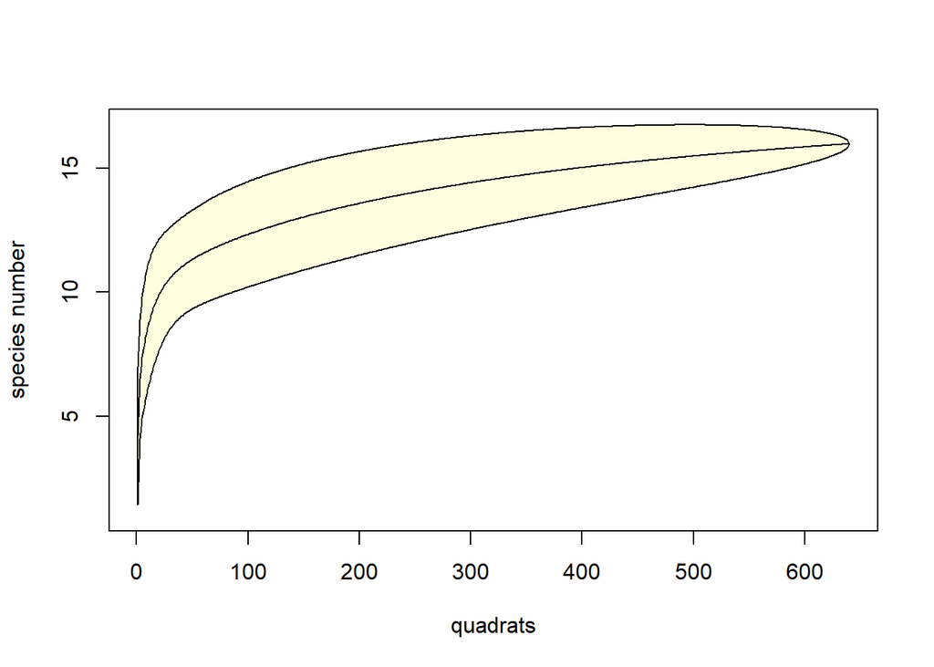

```r
bivalve_species_accumulation
```

### Community NMDS

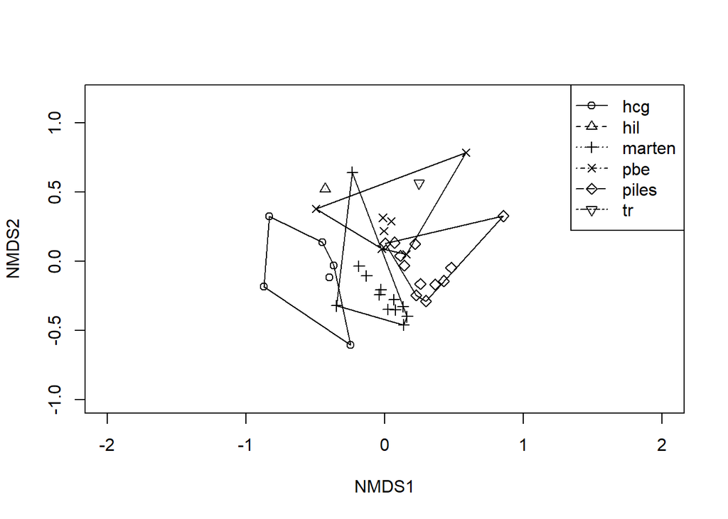

```r
bivalve_NMDS
```

### Seasonal Species Richness

```r
bivalve_seasonal_species_richness
```

```
## geom_path: Each group consists of only one observation. Do you need to
## adjust the group aesthetic?
```

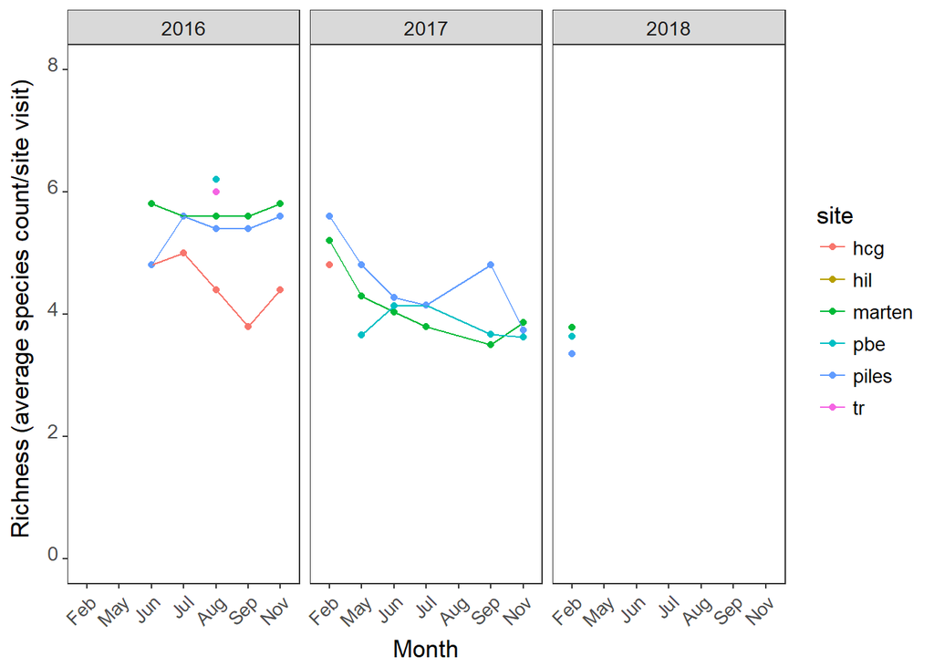

### Seasonal Shannons H

```r
bivalve_seasonal_shannons
```

```
## geom_path: Each group consists of only one observation. Do you need to
## adjust the group aesthetic?
```

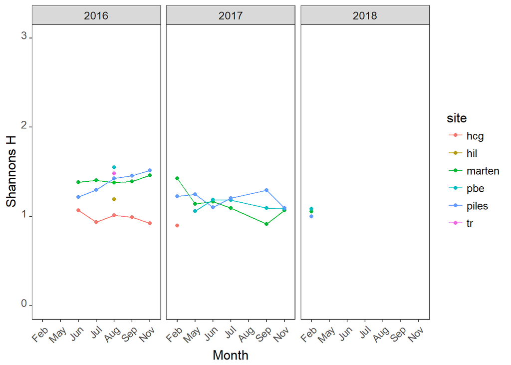

### Species Richness by tide height

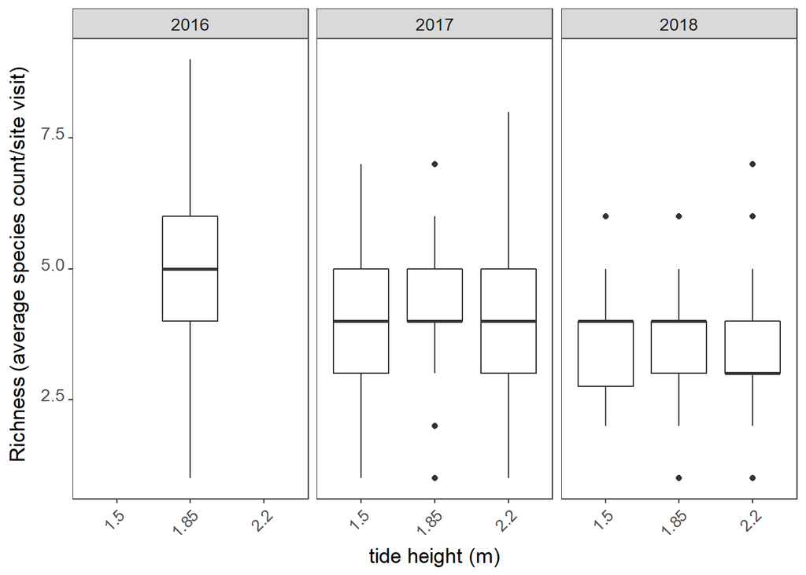

```r
bivalve_tidal_richness
```

Species richness by tide height and year. Tide height is measured as meters above chart datum(mean low tide). Tide height was restricted to 1.85m in 2016.

### Bivalve Abundance by tide height

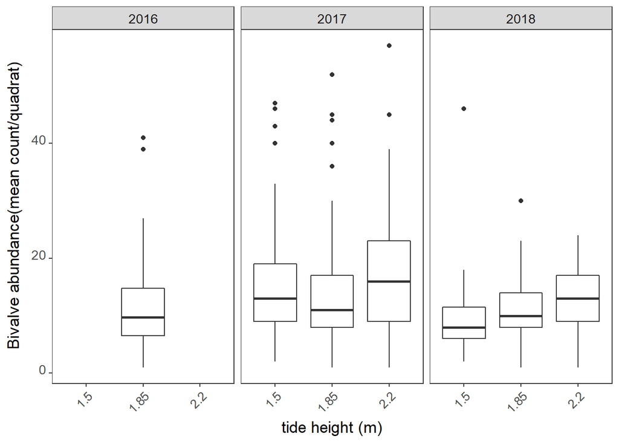

```r
bivalve_tidal_abundance
```

Bivalve abundance by tide height and year. Tide height is measured as meters above chart datum(mean low tide). Tide height was restricted to 1.85m in 2016.

## Individual Species

### Abundances

```r
source("C:/Users/FABS/Desktop/Rwd_Ben/Soft_sed/working_files/Rscript/Soft_sediment/bivalve_individual.R")
```

#### Baltic macoma

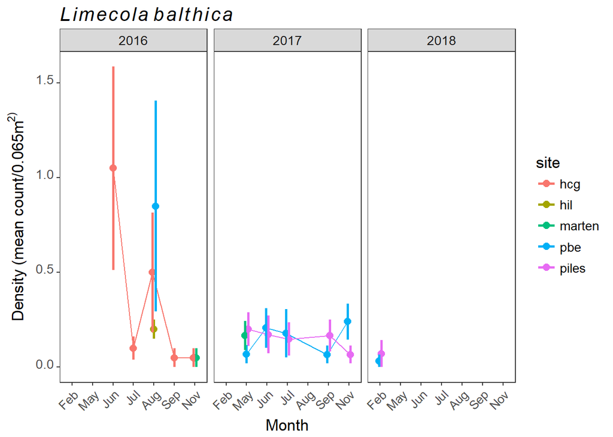

```r
bama
```

#### Bent-nose macoma

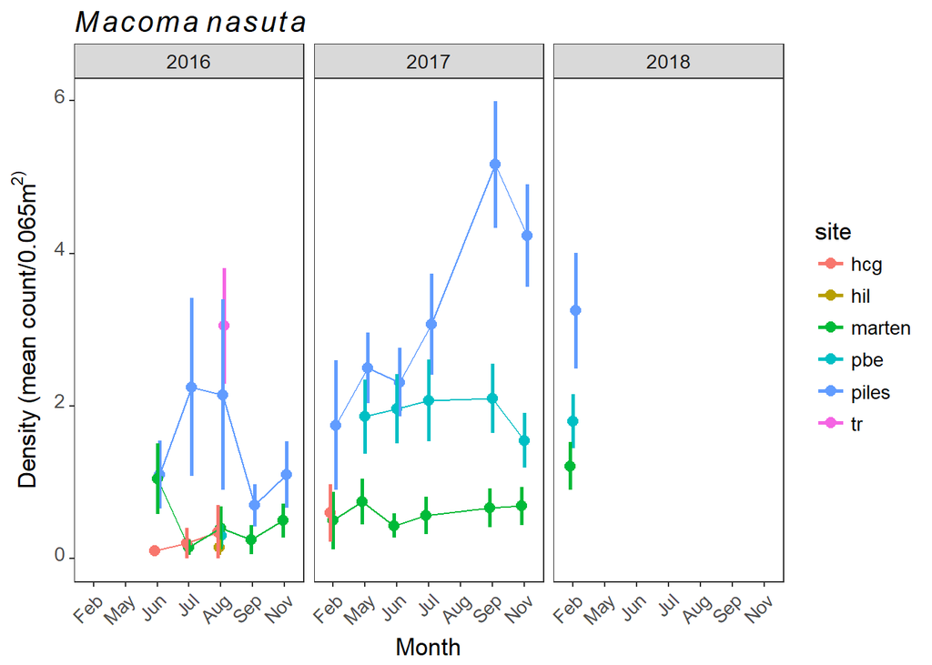

```r
beno
```

#### Butter clam

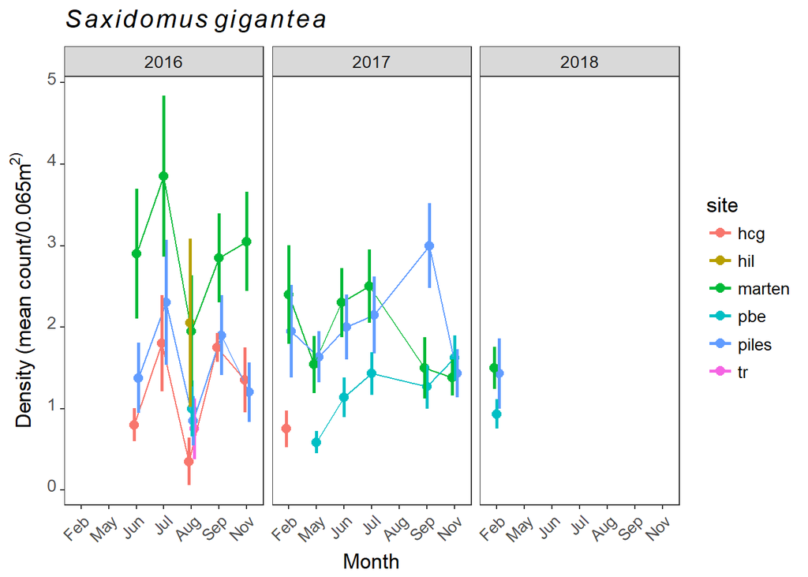

```r
bucl
```

#### Nuttall’s cockle

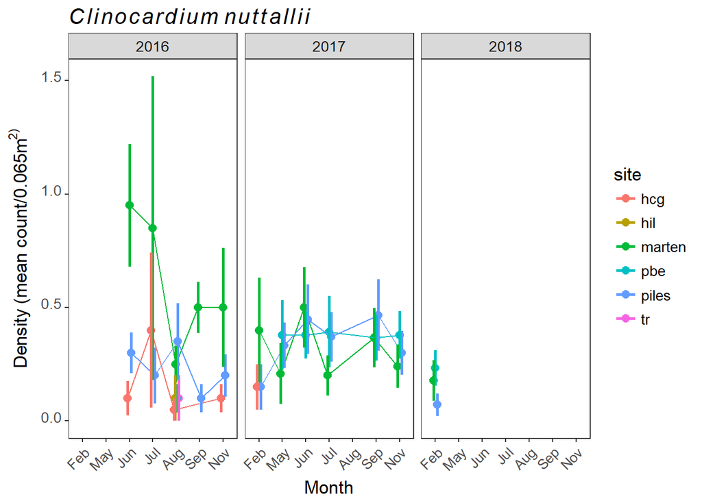

```r
cocl
```

#### Japanese littleneck clam

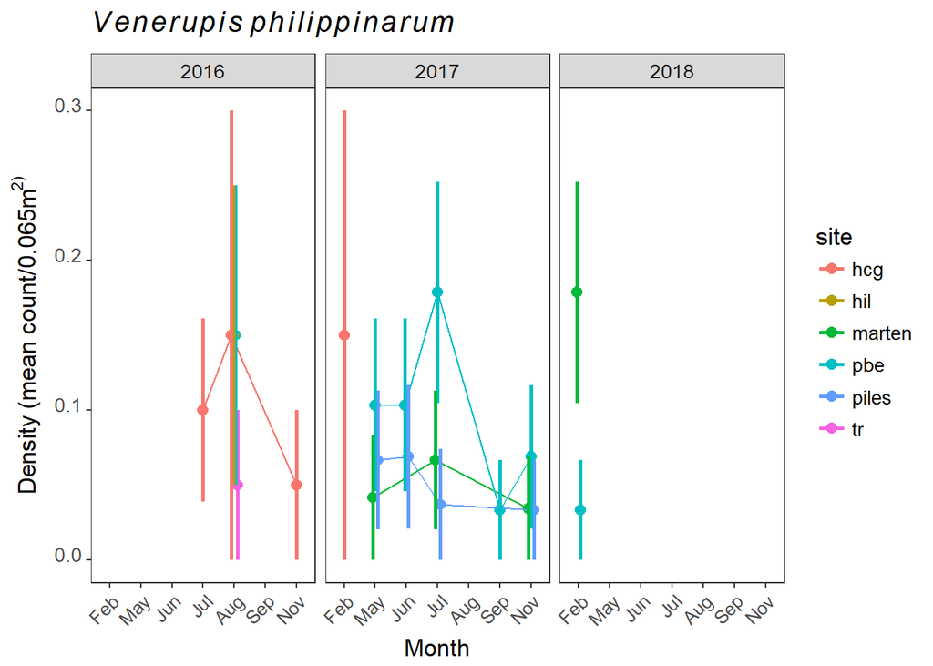

```r
jlne
```

#### Kennerley’s venus

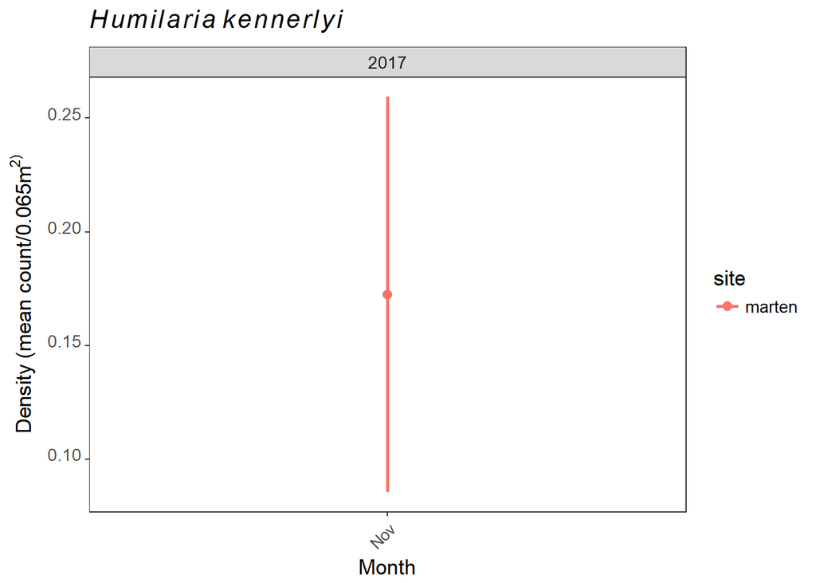

```r
keve
```

#### Softshell clam

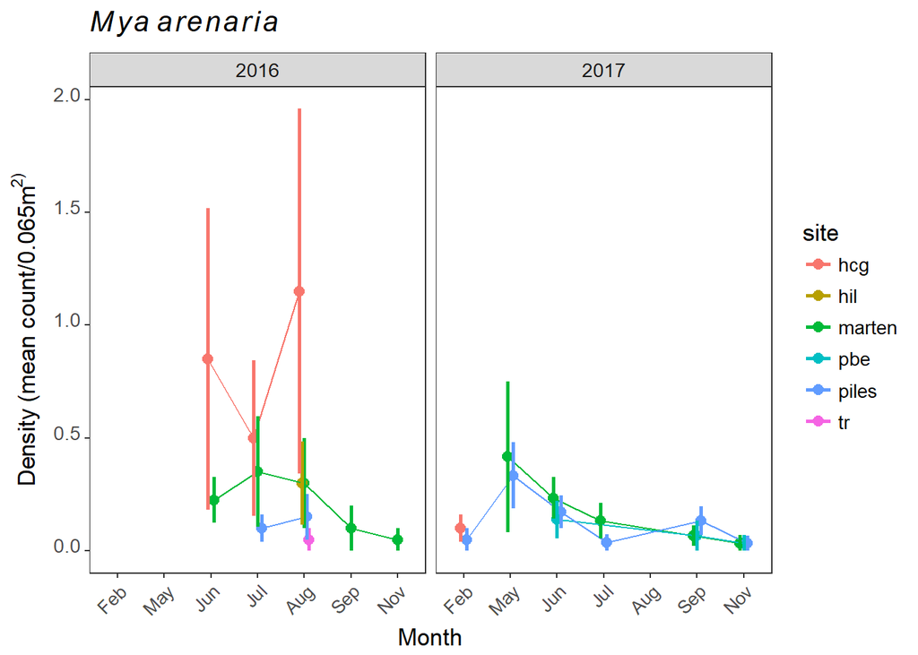

```r
myac
```

#### Pacific littleneck clam

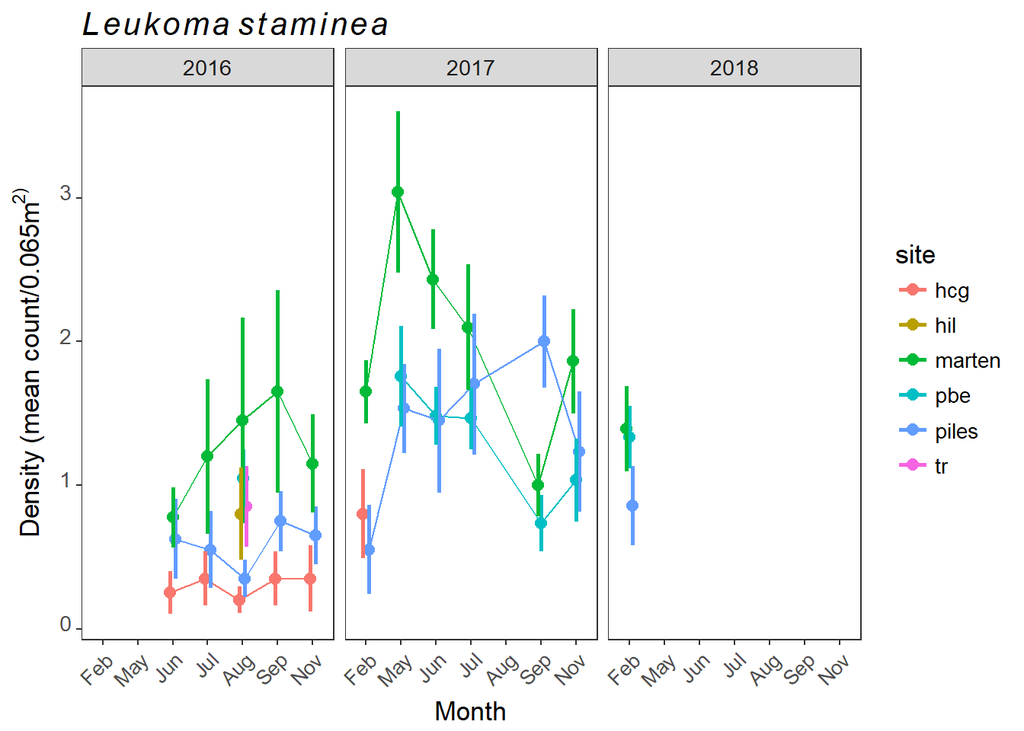

```r
plne
```

#### Pointed macoma

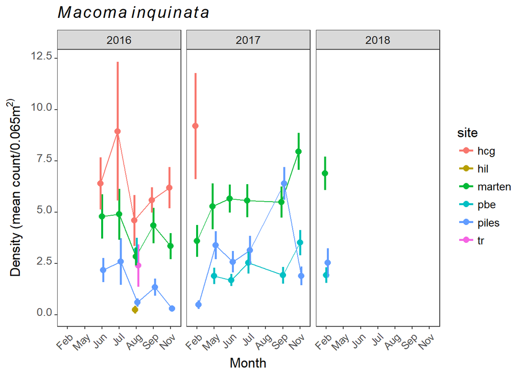

```r
pmac
```

#### Juvenile macoma

Pointend and/or bent-nose macoma.

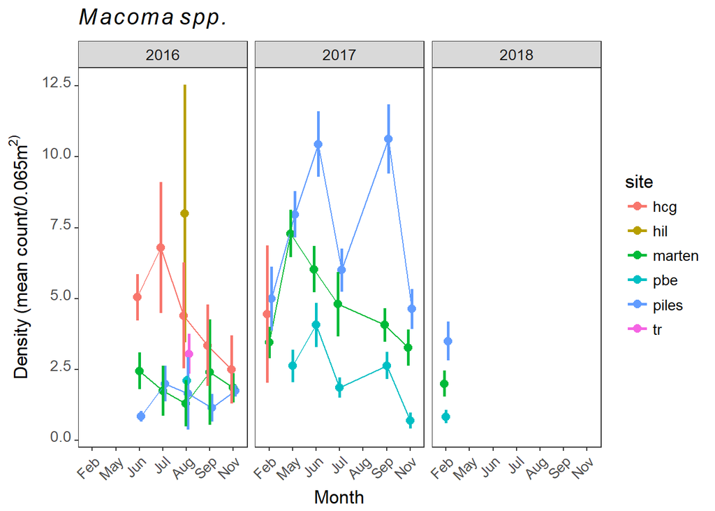

```r
umac
```

#### Dire Whelk

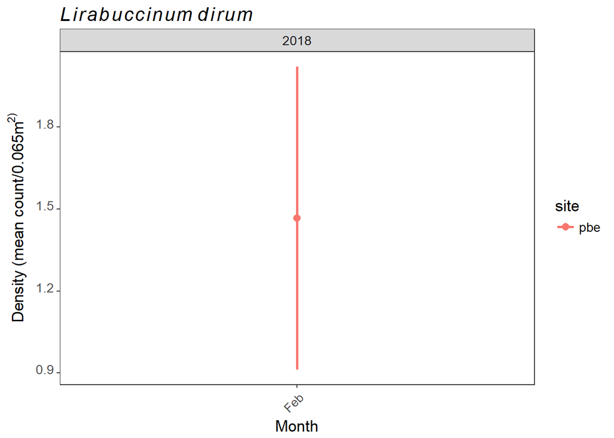

```r
diwe
```

### Length

Focus on second figure. I can figure out how to hide first figure.

```r
source("C:/Users/FABS/Desktop/Rwd_Ben/Soft_sed/working_files/Rscript/Soft_sediment/bivalve_length.R")
```

#### Baltic macoma

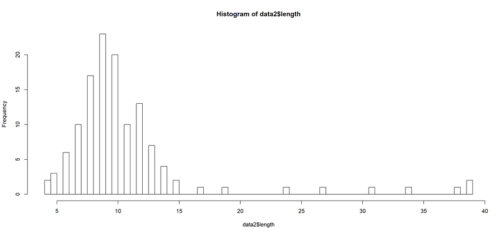

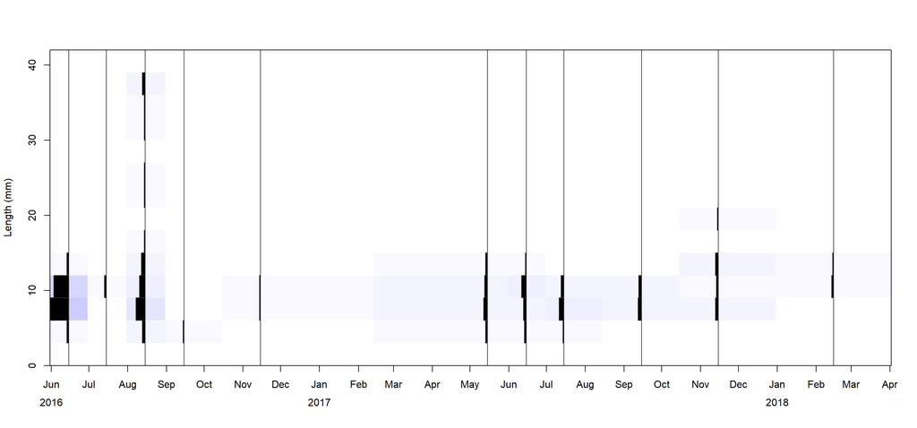

```r
lfq_year_month("bama", "")
```

#### Bent-nose macoma

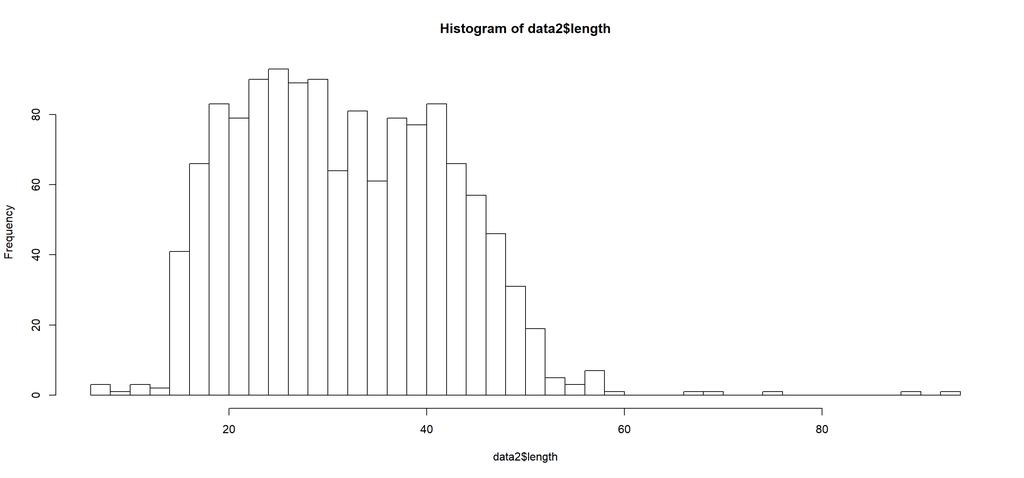

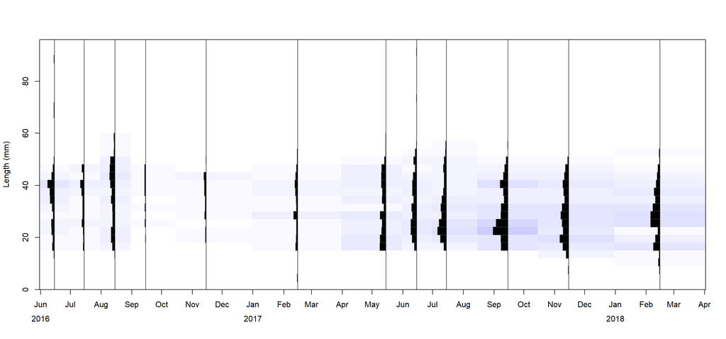

```r
lfq_year_month("beno", "")
```

#### Butter clam

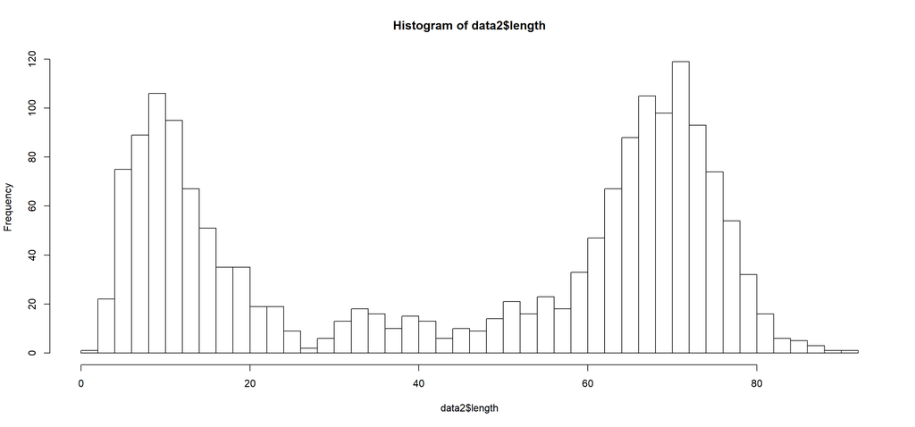

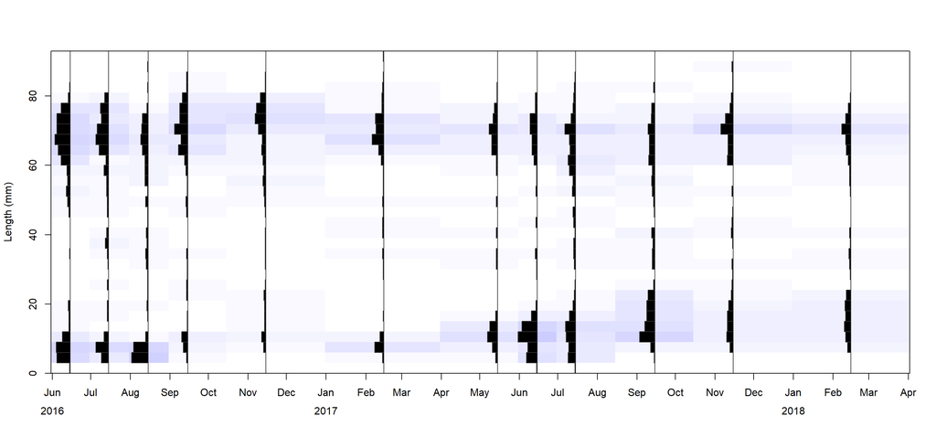

```r
lfq_year_month("bucl", "")
```

#### Nuttall’s cockle

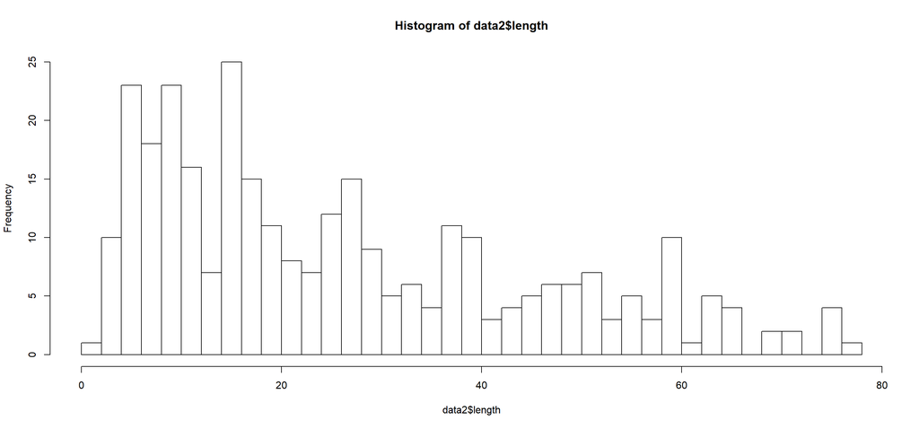

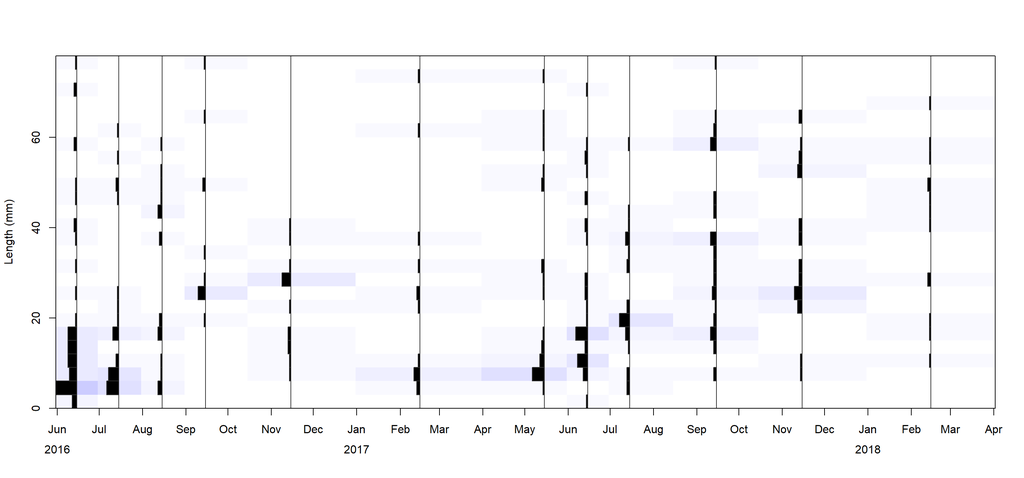

```r
lfq_year_month("cocl", "")
```

#### Japanese littleneck clam

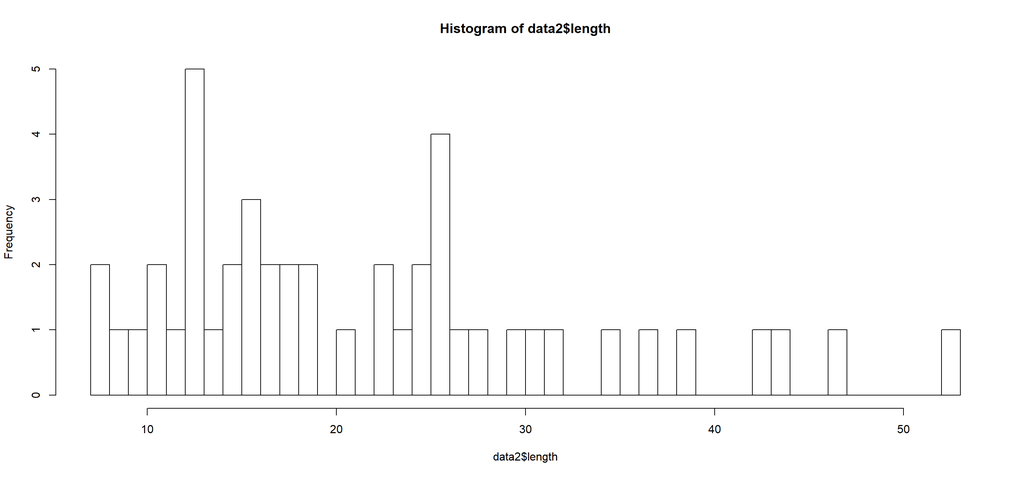

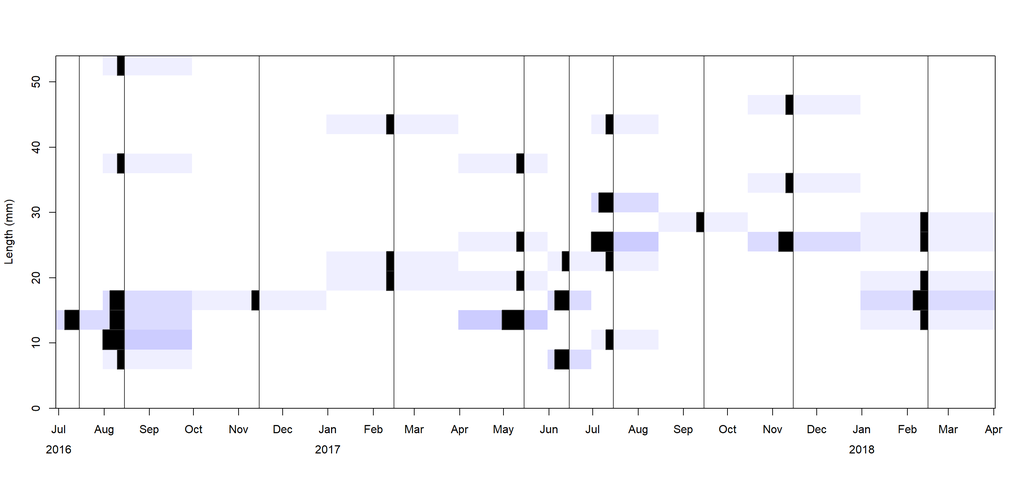

```r
lfq_year_month("jlne", "")
```

#### Kennerley’s venus

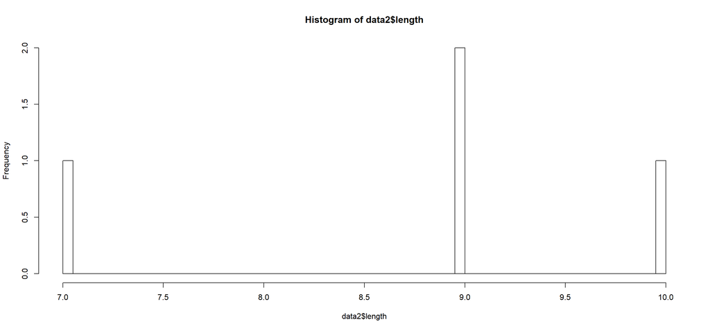

[figure not shown]

```r
lfq_year_month("keve", "")
```